# Risk Factor Analysis

## Outcome Variable

**Outcome Variable:** wasted

## Predictor Variables

**Intervention Variable:** perdiar24

**Adjustment Set:**

unadjusted

## Stratifying Variables

The analysis was stratified on these variable(s):

- agecat
- studyid
- country

## Data Summary

| agecat | studyid | country | perdiar24 | wasted | n_cell | n |
| --- | --- | --- | --- | --- | --- | --- |
| Birth | CMIN | BANGLADESH | 0% | 0 | 4 | 19 |
| Birth | CMIN | BANGLADESH | 0% | 1 | 2 | 19 |
| Birth | CMIN | BANGLADESH | (0%, 5%] | 0 | 3 | 19 |
| Birth | CMIN | BANGLADESH | (0%, 5%] | 1 | 0 | 19 |
| Birth | CMIN | BANGLADESH | >5% | 0 | 8 | 19 |
| Birth | CMIN | BANGLADESH | >5% | 1 | 2 | 19 |
| Birth | CONTENT | PERU | 0% | 0 | 0 | 2 |
| Birth | CONTENT | PERU | 0% | 1 | 0 | 2 |
| Birth | CONTENT | PERU | (0%, 5%] | 0 | 1 | 2 |
| Birth | CONTENT | PERU | (0%, 5%] | 1 | 0 | 2 |
| Birth | CONTENT | PERU | >5% | 0 | 1 | 2 |
| Birth | CONTENT | PERU | >5% | 1 | 0 | 2 |
| Birth | EE | PAKISTAN | 0% | 0 | 100 | 177 |
| Birth | EE | PAKISTAN | 0% | 1 | 15 | 177 |
| Birth | EE | PAKISTAN | (0%, 5%] | 0 | 55 | 177 |
| Birth | EE | PAKISTAN | (0%, 5%] | 1 | 7 | 177 |
| Birth | EE | PAKISTAN | >5% | 0 | 0 | 177 |
| Birth | EE | PAKISTAN | >5% | 1 | 0 | 177 |
| Birth | JiVitA-4 | BANGLADESH | 0% | 0 | 53 | 2396 |
| Birth | JiVitA-4 | BANGLADESH | 0% | 1 | 8 | 2396 |
| Birth | JiVitA-4 | BANGLADESH | (0%, 5%] | 0 | 1885 | 2396 |
| Birth | JiVitA-4 | BANGLADESH | (0%, 5%] | 1 | 206 | 2396 |
| Birth | JiVitA-4 | BANGLADESH | >5% | 0 | 219 | 2396 |
| Birth | JiVitA-4 | BANGLADESH | >5% | 1 | 25 | 2396 |
| Birth | MAL-ED | BANGLADESH | 0% | 0 | 13 | 215 |
| Birth | MAL-ED | BANGLADESH | 0% | 1 | 1 | 215 |
| Birth | MAL-ED | BANGLADESH | (0%, 5%] | 0 | 101 | 215 |
| Birth | MAL-ED | BANGLADESH | (0%, 5%] | 1 | 26 | 215 |
| Birth | MAL-ED | BANGLADESH | >5% | 0 | 65 | 215 |
| Birth | MAL-ED | BANGLADESH | >5% | 1 | 9 | 215 |

[output cut: 234 more lines]

The following strata were considered:

- agecat: 24 months, studyid: CMIN, country: BANGLADESH
- agecat: 24 months, studyid: CONTENT, country: PERU
- agecat: 24 months, studyid: EE, country: PAKISTAN
- agecat: 24 months, studyid: JiVitA-4, country: BANGLADESH
- agecat: 24 months, studyid: MAL-ED, country: BANGLADESH
- agecat: 24 months, studyid: MAL-ED, country: BRAZIL
- agecat: 24 months, studyid: MAL-ED, country: INDIA
- agecat: 24 months, studyid: MAL-ED, country: NEPAL
- agecat: 24 months, studyid: MAL-ED, country: PERU
- agecat: 24 months, studyid: MAL-ED, country: SOUTH AFRICA
- agecat: 24 months, studyid: MAL-ED, country: TANZANIA, UNITED REPUBLIC OF
- agecat: 24 months, studyid: NIH-Birth, country: BANGLADESH
- agecat: 24 months, studyid: NIH-Crypto, country: BANGLADESH
- agecat: 24 months, studyid: PROVIDE, country: BANGLADESH
- agecat: 6 months, studyid: CMIN, country: BANGLADESH
- agecat: 6 months, studyid: CONTENT, country: PERU
- agecat: 6 months, studyid: EE, country: PAKISTAN
- agecat: 6 months, studyid: Guatemala BSC, country: GUATEMALA
- agecat: 6 months, studyid: JiVitA-4, country: BANGLADESH
- agecat: 6 months, studyid: MAL-ED, country: BANGLADESH
- agecat: 6 months, studyid: MAL-ED, country: BRAZIL
- agecat: 6 months, studyid: MAL-ED, country: INDIA
- agecat: 6 months, studyid: MAL-ED, country: NEPAL
- agecat: 6 months, studyid: MAL-ED, country: PERU
- agecat: 6 months, studyid: MAL-ED, country: SOUTH AFRICA
- agecat: 6 months, studyid: MAL-ED, country: TANZANIA, UNITED REPUBLIC OF
- agecat: 6 months, studyid: NIH-Birth, country: BANGLADESH
- agecat: 6 months, studyid: NIH-Crypto, country: BANGLADESH
- agecat: 6 months, studyid: PROVIDE, country: BANGLADESH
- agecat: 6 months, studyid: SAS-FoodSuppl, country: INDIA
- agecat: Birth, studyid: CMIN, country: BANGLADESH
- agecat: Birth, studyid: CONTENT, country: PERU
- agecat: Birth, studyid: EE, country: PAKISTAN
- agecat: Birth, studyid: JiVitA-4, country: BANGLADESH
- agecat: Birth, studyid: MAL-ED, country: BANGLADESH
- agecat: Birth, studyid: MAL-ED, country: BRAZIL
- agecat: Birth, studyid: MAL-ED, country: INDIA
- agecat: Birth, studyid: MAL-ED, country: NEPAL
- agecat: Birth, studyid: MAL-ED, country: PERU
- agecat: Birth, studyid: MAL-ED, country: SOUTH AFRICA
- agecat: Birth, studyid: MAL-ED, country: TANZANIA, UNITED REPUBLIC OF
- agecat: Birth, studyid: NIH-Birth, country: BANGLADESH
- agecat: Birth, studyid: NIH-Crypto, country: BANGLADESH
- agecat: Birth, studyid: PROVIDE, country: BANGLADESH

### Dropped Strata

Some strata were dropped due to rare outcomes:

- agecat: Birth, studyid: CMIN, country: BANGLADESH
- agecat: Birth, studyid: CONTENT, country: PERU
- agecat: Birth, studyid: EE, country: PAKISTAN
- agecat: Birth, studyid: MAL-ED, country: BANGLADESH
- agecat: Birth, studyid: MAL-ED, country: BRAZIL
- agecat: Birth, studyid: MAL-ED, country: INDIA
- agecat: Birth, studyid: MAL-ED, country: NEPAL
- agecat: Birth, studyid: MAL-ED, country: PERU
- agecat: Birth, studyid: MAL-ED, country: SOUTH AFRICA
- agecat: Birth, studyid: MAL-ED, country: TANZANIA, UNITED REPUBLIC OF
- agecat: 6 months, studyid: CMIN, country: BANGLADESH
- agecat: 6 months, studyid: CONTENT, country: PERU
- agecat: 6 months, studyid: EE, country: PAKISTAN
- agecat: 6 months, studyid: Guatemala BSC, country: GUATEMALA
- agecat: 6 months, studyid: MAL-ED, country: BANGLADESH
- agecat: 6 months, studyid: MAL-ED, country: BRAZIL
- agecat: 6 months, studyid: MAL-ED, country: INDIA
- agecat: 6 months, studyid: MAL-ED, country: NEPAL
- agecat: 6 months, studyid: MAL-ED, country: PERU
- agecat: 6 months, studyid: MAL-ED, country: SOUTH AFRICA
- agecat: 6 months, studyid: MAL-ED, country: TANZANIA, UNITED REPUBLIC OF
- agecat: 6 months, studyid: NIH-Birth, country: BANGLADESH
- agecat: 6 months, studyid: NIH-Crypto, country: BANGLADESH
- agecat: 6 months, studyid: PROVIDE, country: BANGLADESH
- agecat: 24 months, studyid: CMIN, country: BANGLADESH
- agecat: 24 months, studyid: CONTENT, country: PERU
- agecat: 24 months, studyid: EE, country: PAKISTAN
- agecat: 24 months, studyid: MAL-ED, country: BANGLADESH
- agecat: 24 months, studyid: MAL-ED, country: BRAZIL
- agecat: 24 months, studyid: MAL-ED, country: INDIA
- agecat: 24 months, studyid: MAL-ED, country: NEPAL
- agecat: 24 months, studyid: MAL-ED, country: PERU
- agecat: 24 months, studyid: MAL-ED, country: SOUTH AFRICA
- agecat: 24 months, studyid: MAL-ED, country: TANZANIA, UNITED REPUBLIC OF
- agecat: 24 months, studyid: NIH-Birth, country: BANGLADESH
- agecat: 24 months, studyid: PROVIDE, country: BANGLADESH

## Methods Detail

We’re interested in the causal parameters $E[Y_a]$ for all values of $a \in \mathcal{A}$. These parameters represent the mean outcome if, possibly contrary to fact, we intervened to set all units to have $A=a$. Under the randomization and positivity assumptions, these are identified by the statistical parameters $\psi_a=E_W[E_{Y|A,W}(Y|A=a,W)]$. In addition, we’re interested in the mean of $Y$, $E[Y]$ under no intervention (the observed mean). We will estimate these parameters by using SuperLearner to fit the relevant likelihood factors – $E_{Y|A,W}(Y|A=a,W)$ and $p(A=a|W)$, and then updating our likelihood fit using a joint TMLE.

For unadjusted analyses ($W=\{\}$), initial likelihoods were estimated using Lrnr_glm to estimate the simple $E(Y|A)$ and Lrnr_mean to estimate $p(A)$. For adjusted analyses, a small library containing Lrnr_glmnet, Lrnr_xgboost, and Lrnr_mean was used.

Having estimated these parameters, we will then use the delta method to estimate relative risks and attributable risks relative to a prespecified baseline level of $A$.

# Results Detail

## Results Plots

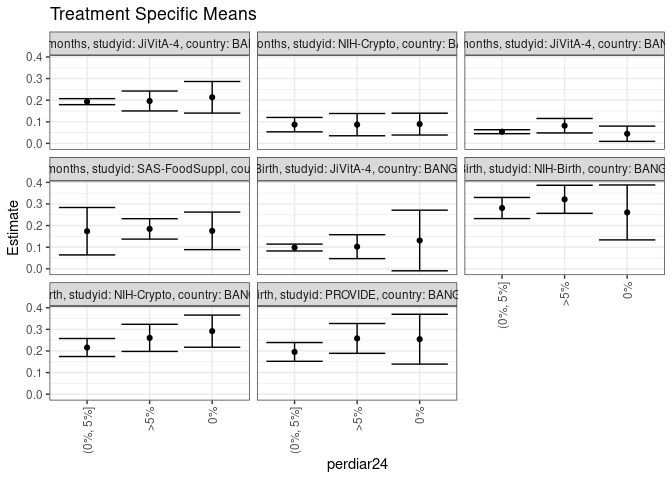

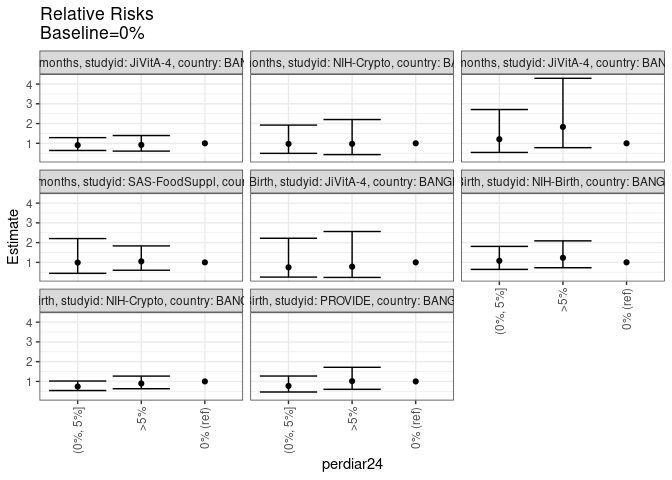

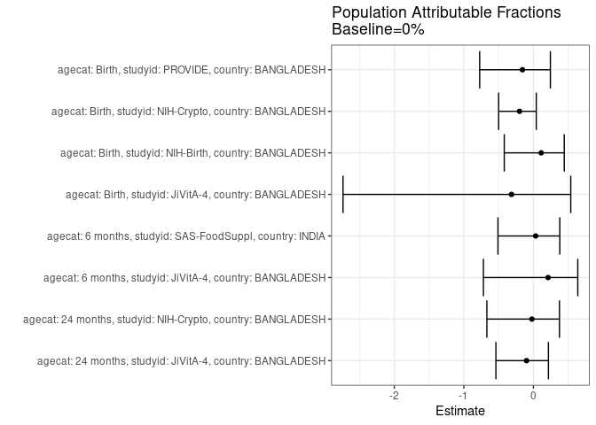

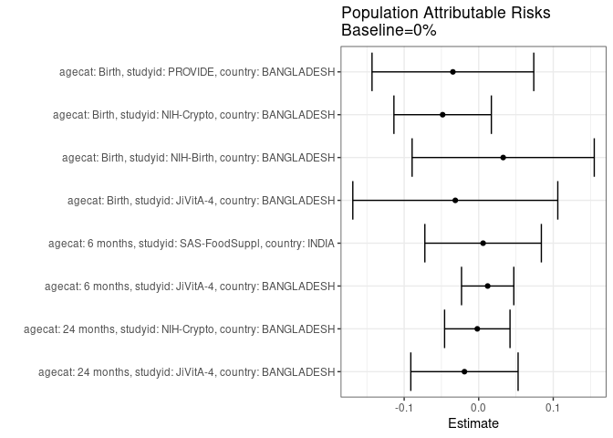

## Results Table

### Parameter: TSM

| agecat | studyid | country | intervention_level | baseline_level | estimate | ci_lower | ci_upper |
| --- | --- | --- | --- | --- | --- | --- | --- |
| Birth | JiVitA-4 | BANGLADESH | 0% | NA | 0.1311475 | -0.0090976 | 0.2713927 |
| Birth | JiVitA-4 | BANGLADESH | (0%, 5%] | NA | 0.0985175 | 0.0826046 | 0.1144303 |
| Birth | JiVitA-4 | BANGLADESH | >5% | NA | 0.1024590 | 0.0470775 | 0.1578405 |
| Birth | NIH-Birth | BANGLADESH | 0% | NA | 0.2608696 | 0.1338644 | 0.3878747 |
| Birth | NIH-Birth | BANGLADESH | (0%, 5%] | NA | 0.2813456 | 0.2325664 | 0.3301247 |
| Birth | NIH-Birth | BANGLADESH | >5% | NA | 0.3216080 | 0.2566541 | 0.3865620 |
| Birth | NIH-Crypto | BANGLADESH | 0% | NA | 0.2916667 | 0.2173756 | 0.3659577 |
| Birth | NIH-Crypto | BANGLADESH | (0%, 5%] | NA | 0.2160000 | 0.1743203 | 0.2576797 |
| Birth | NIH-Crypto | BANGLADESH | >5% | NA | 0.2606383 | 0.1978434 | 0.3234332 |
| Birth | PROVIDE | BANGLADESH | 0% | NA | 0.2545455 | 0.1393147 | 0.3697762 |
| Birth | PROVIDE | BANGLADESH | (0%, 5%] | NA | 0.1956522 | 0.1522818 | 0.2390225 |
| Birth | PROVIDE | BANGLADESH | >5% | NA | 0.2580645 | 0.1891139 | 0.3270151 |
| 6 months | JiVitA-4 | BANGLADESH | 0% | NA | 0.0448718 | 0.0095437 | 0.0801999 |
| 6 months | JiVitA-4 | BANGLADESH | (0%, 5%] | NA | 0.0541777 | 0.0449929 | 0.0633625 |
| 6 months | JiVitA-4 | BANGLADESH | >5% | NA | 0.0820611 | 0.0486177 | 0.1155045 |
| 6 months | SAS-FoodSuppl | INDIA | 0% | NA | 0.1756757 | 0.0888578 | 0.2624936 |
| 6 months | SAS-FoodSuppl | INDIA | (0%, 5%] | NA | 0.1739130 | 0.0642348 | 0.2835912 |
| 6 months | SAS-FoodSuppl | INDIA | >5% | NA | 0.1846154 | 0.1373929 | 0.2318379 |
| 24 months | JiVitA-4 | BANGLADESH | 0% | NA | 0.2134146 | 0.1402654 | 0.2865638 |
| 24 months | JiVitA-4 | BANGLADESH | (0%, 5%] | NA | 0.1932876 | 0.1793181 | 0.2072571 |
| 24 months | JiVitA-4 | BANGLADESH | >5% | NA | 0.1963190 | 0.1502014 | 0.2424366 |
| 24 months | NIH-Crypto | BANGLADESH | 0% | NA | 0.0894309 | 0.0389510 | 0.1399108 |
| 24 months | NIH-Crypto | BANGLADESH | (0%, 5%] | NA | 0.0869565 | 0.0536819 | 0.1202312 |
| 24 months | NIH-Crypto | BANGLADESH | >5% | NA | 0.0869565 | 0.0354077 | 0.1385054 |

### Parameter: E(Y)

| agecat | studyid | country | intervention_level | baseline_level | estimate | ci_lower | ci_upper |
| --- | --- | --- | --- | --- | --- | --- | --- |
| Birth | JiVitA-4 | BANGLADESH | NA | NA | 0.0997496 | 0.0843744 | 0.1151247 |
| Birth | NIH-Birth | BANGLADESH | NA | NA | 0.2937063 | 0.2563487 | 0.3310639 |
| Birth | NIH-Crypto | BANGLADESH | NA | NA | 0.2432815 | 0.2116319 | 0.2749310 |
| Birth | PROVIDE | BANGLADESH | NA | NA | 0.2199248 | 0.1846953 | 0.2551543 |
| 6 months | JiVitA-4 | BANGLADESH | NA | NA | 0.0569005 | 0.0480577 | 0.0657432 |
| 6 months | SAS-FoodSuppl | INDIA | NA | NA | 0.1815789 | 0.1427684 | 0.2203895 |
| 24 months | JiVitA-4 | BANGLADESH | NA | NA | 0.1942978 | 0.1810880 | 0.2075076 |
| 24 months | NIH-Crypto | BANGLADESH | NA | NA | 0.0875486 | 0.0630907 | 0.1120065 |

### Parameter: RR

| agecat | studyid | country | intervention_level | baseline_level | estimate | ci_lower | ci_upper |
| --- | --- | --- | --- | --- | --- | --- | --- |
| Birth | JiVitA-4 | BANGLADESH | 0% | 0% | 1.0000000 | 1.0000000 | 1.000000 |
| Birth | JiVitA-4 | BANGLADESH | (0%, 5%] | 0% | 0.7511956 | 0.2542327 | 2.219600 |
| Birth | JiVitA-4 | BANGLADESH | >5% | 0% | 0.7812500 | 0.2381172 | 2.563241 |
| Birth | NIH-Birth | BANGLADESH | 0% | 0% | 1.0000000 | 1.0000000 | 1.000000 |
| Birth | NIH-Birth | BANGLADESH | (0%, 5%] | 0% | 1.0784913 | 0.6432380 | 1.808263 |
| Birth | NIH-Birth | BANGLADESH | >5% | 0% | 1.2328308 | 0.7277703 | 2.088395 |
| Birth | NIH-Crypto | BANGLADESH | 0% | 0% | 1.0000000 | 1.0000000 | 1.000000 |
| Birth | NIH-Crypto | BANGLADESH | (0%, 5%] | 0% | 0.7405714 | 0.5380071 | 1.019403 |
| Birth | NIH-Crypto | BANGLADESH | >5% | 0% | 0.8936170 | 0.6293401 | 1.268871 |
| Birth | PROVIDE | BANGLADESH | 0% | 0% | 1.0000000 | 1.0000000 | 1.000000 |
| Birth | PROVIDE | BANGLADESH | (0%, 5%] | 0% | 0.7686335 | 0.4643146 | 1.272408 |
| Birth | PROVIDE | BANGLADESH | >5% | 0% | 1.0138249 | 0.5993384 | 1.714959 |
| 6 months | JiVitA-4 | BANGLADESH | 0% | 0% | 1.0000000 | 1.0000000 | 1.000000 |
| 6 months | JiVitA-4 | BANGLADESH | (0%, 5%] | 0% | 1.2073888 | 0.5378249 | 2.710525 |
| 6 months | JiVitA-4 | BANGLADESH | >5% | 0% | 1.8287895 | 0.7794357 | 4.290888 |
| 6 months | SAS-FoodSuppl | INDIA | 0% | 0% | 1.0000000 | 1.0000000 | 1.000000 |
| 6 months | SAS-FoodSuppl | INDIA | (0%, 5%] | 0% | 0.9899666 | 0.4442801 | 2.205892 |
| 6 months | SAS-FoodSuppl | INDIA | >5% | 0% | 1.0508876 | 0.6024010 | 1.833272 |
| 24 months | JiVitA-4 | BANGLADESH | 0% | 0% | 1.0000000 | 1.0000000 | 1.000000 |
| 24 months | JiVitA-4 | BANGLADESH | (0%, 5%] | 0% | 0.9056905 | 0.6374341 | 1.286839 |
| 24 months | JiVitA-4 | BANGLADESH | >5% | 0% | 0.9198948 | 0.6069822 | 1.394121 |
| 24 months | NIH-Crypto | BANGLADESH | 0% | 0% | 1.0000000 | 1.0000000 | 1.000000 |
| 24 months | NIH-Crypto | BANGLADESH | (0%, 5%] | 0% | 0.9723320 | 0.4916462 | 1.922988 |
| 24 months | NIH-Crypto | BANGLADESH | >5% | 0% | 0.9723320 | 0.4288637 | 2.204499 |

### Parameter: PAR

| agecat | studyid | country | intervention_level | baseline_level | estimate | ci_lower | ci_upper |
| --- | --- | --- | --- | --- | --- | --- | --- |
| Birth | JiVitA-4 | BANGLADESH | 0% | NA | -0.0313980 | -0.1689018 | 0.1061058 |
| Birth | NIH-Birth | BANGLADESH | 0% | NA | 0.0328367 | -0.0893579 | 0.1550313 |
| Birth | NIH-Crypto | BANGLADESH | 0% | NA | -0.0483852 | -0.1137503 | 0.0169799 |
| Birth | PROVIDE | BANGLADESH | 0% | NA | -0.0346206 | -0.1431277 | 0.0738864 |
| 6 months | JiVitA-4 | BANGLADESH | 0% | NA | 0.0120287 | -0.0230586 | 0.0471160 |
| 6 months | SAS-FoodSuppl | INDIA | 0% | NA | 0.0059033 | -0.0722505 | 0.0840570 |
| 24 months | JiVitA-4 | BANGLADESH | 0% | NA | -0.0191169 | -0.0910834 | 0.0528497 |
| 24 months | NIH-Crypto | BANGLADESH | 0% | NA | -0.0018823 | -0.0457780 | 0.0420135 |

### Parameter: PAF

| agecat | studyid | country | intervention_level | baseline_level | estimate | ci_lower | ci_upper |
| --- | --- | --- | --- | --- | --- | --- | --- |
| Birth | JiVitA-4 | BANGLADESH | 0% | NA | -0.3147678 | -2.7366393 | 0.5373879 |
| Birth | NIH-Birth | BANGLADESH | 0% | NA | 0.1118012 | -0.4187573 | 0.4439521 |
| Birth | NIH-Crypto | BANGLADESH | 0% | NA | -0.1988857 | -0.4996971 | 0.0415886 |
| Birth | PROVIDE | BANGLADESH | 0% | NA | -0.1574204 | -0.7722994 | 0.2441334 |
| 6 months | JiVitA-4 | BANGLADESH | 0% | NA | 0.2113986 | -0.7184872 | 0.6381165 |
| 6 months | SAS-FoodSuppl | INDIA | 0% | NA | 0.0325108 | -0.5095190 | 0.3799115 |
| 24 months | JiVitA-4 | BANGLADESH | 0% | NA | -0.0983894 | -0.5389858 | 0.2160686 |
| 24 months | NIH-Crypto | BANGLADESH | 0% | NA | -0.0214995 | -0.6687540 | 0.3747063 |